# Avaliação Continuada - Aula 4

### Base de Dados - Turma B

Os exercícios de avaliação continuada da **Turma B** serão realizados com a base de dados de passageiros da embarcação Titanic, chamada de `titanic`. Essa é uma base de dados que é disponibilizada como dados de exemplo pela própria biblioteca `seaborn`, por meio da função `load_dataset`.

**Execute a célula a seguir para importar as bibliotecas de que vamos precisar e criar a variável `titanic` com nossa base de dados.**

```python
# Importando a biblioteca seaborn
import seaborn as sns

# Carregando a base de dados 'titanic'
titanic = sns.load_dataset("titanic")

titanic.head()
```

|  | survived | pclass | sex | age | sibsp | parch | fare | embarked | class | who | adult_male | deck | embark_town | alive | alone |
| --- | --- | --- | --- | --- | --- | --- | --- | --- | --- | --- | --- | --- | --- | --- | --- |
| 0 | 0 | 3 | male | 22.0 | 1 | 0 | 7.2500 | S | Third | man | True | NaN | Southampton | no | False |
| 1 | 1 | 1 | female | 38.0 | 1 | 0 | 71.2833 | C | First | woman | False | C | Cherbourg | yes | False |
| 2 | 1 | 3 | female | 26.0 | 0 | 0 | 7.9250 | S | Third | woman | False | NaN | Southampton | yes | True |
| 3 | 1 | 1 | female | 35.0 | 1 | 0 | 53.1000 | S | First | woman | False | C | Southampton | yes | False |
| 4 | 0 | 3 | male | 35.0 | 0 | 0 | 8.0500 | S | Third | man | True | NaN | Southampton | no | True |

### Sobre os dados

A base `titanic` contém informações sobre 891 passageiros do Titanic (unidade de observação). A base contém 15 variáveis (colunas), incluindo o sexo e a idade do passageiro, se ele sobreviveu ou não ao naufrágio, o preço pago pela viagem, a classe em que ele estava situado (Primeira Classe, Segunda Classe ou Terceira Classe), dentre outras informações.

No exercício de hoje, vamos utilizar apenas a variável `age`, referente à idade dos passageiros do `titanic`. Queremos analisar como as idades dos passageiros estão distribuídas.

### Exercício de hoje - Parte 1

- Utilize a função `sns.histplot()` para criar um histograma que mostra o formato da distribuição da coluna `"age"`.
- Escolha também uma cor para seu gráfico, diferente da cor padrão. Consulte [aqui](https://matplotlib.org/3.1.0/gallery/color/named_colors.html) uma lista de nomes de cores, se precisar.

Após escrever a linha de código de sua resposta, execute a célula para mostrar o gráfico a partir da base `titanic`.

**Importante: antes de executar o código da sua resposta, não deixe de executar a célula de código que está no início deste caderno, que importa as bibliotecas e carrega os dados.**

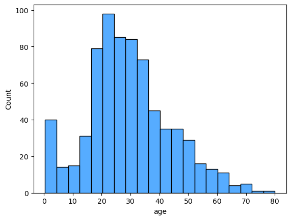

```python
## Escreva sua resposta abaixo e execute a célula para gerar o gráfico
sns.histplot(
    x="age", # Não é ideal, mas o aluno pode plotar o histograma no eixo y
    color="dodgerblue", # O aluno pode escolher outra cor
    data=titanic
)
```

### Exercício de hoje - Parte 2

- Copie o código do gráfico anterior.
- Agora você deve modificar os bins do seu histograma, estabelecendo o valor de `10` para o intervalo de cada bin (`binwidth`).

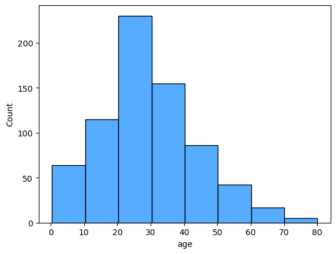

```python
## Escreva sua resposta abaixo e execute a célula para gerar o gráfico
sns.histplot(
    x="age",
    binwidth=10, # 'binwidth' deve ser 10, o resto igual ao anterior
    color="dodgerblue",
    data=titanic
)
```